# R Notebook

Shiva Neelakantan

```r
library(leaps)
library(ISLR2)
```

# Problem 1

## 1a through 1c

```r
X1 = rnorm(n=100)
err = rnorm(n=100,mean=0,sd=2)

b0 = 2
b1 = 6
b2 = 4
b3 = 5

Y = b0 + b1*X1 + b2*(X1^2) + b3*(X1^3) + err
```

## 1d

```r
df = data.frame(X1, Y)
idx = sample(1:100, 50, rep=FALSE)
train.split = df[idx, ]
test.split = df[-idx, ]
```

## 1e

```r
train.mse = c()
test.mse = c()
models = c()
for (i in 1:10) {
  models[[i]] = lm(Y~poly(X1, i), train.split)
  train.mse[[i]] = mean((train.split$Y - models[[i]]$fitted.values) ^ 2)

  y_pred = predict(models[[i]], test.split)
  test.mse[[i]] = mean((test.split$Y - y_pred) ^ 2)
}
```

## 1f

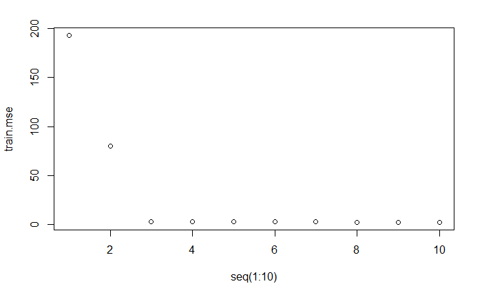

For the linear and quadratic polynomial models, the MSE is pretty high. However, for the cubic model onward, the MSE is significantly lower. This shows us that we can generate models with much higher training accuracy if we increase the polynomial degree of our training model.

## 1g

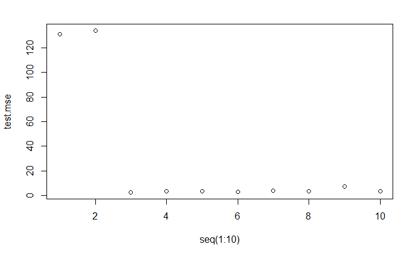

```r
plot(seq(1:10), test.mse)
```

Similar to the training MSE plot, we can see here that after the first two models, the MSE decreases significantly. In terms of the bias-variance trade-off, we can see that over time, we are starting to over fit the data, because we use the same set of training data for each iteration.

## 1h

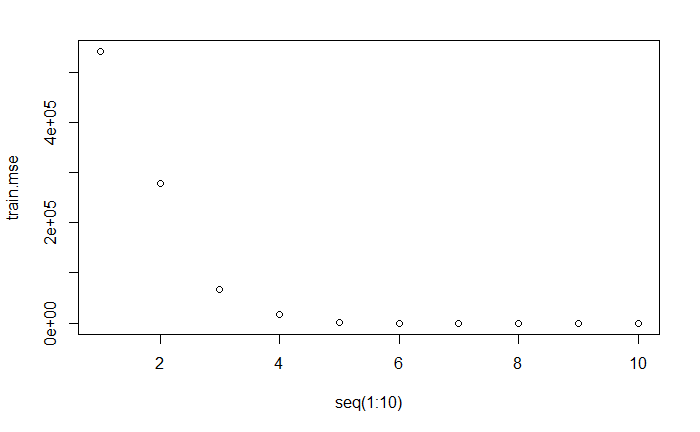

```r
b4 = 9
b5 = 2
b6 = 4
b7 = 7
err = rnorm(n=100,mean=0,sd=2)
Ynew = b0 + b1*X1 + b2*X1^2 + b3*X1^3 + b4*1^4 + b5*X1^5 + b6*1^6 + b7*X1^7 + err

df = data.frame(X1, Ynew)
idx = sample(1:100, 50, rep=FALSE)
train.split = df[idx, ]
test.split = df[-idx, ]

train.mse = c()
test.mse = c()
models = c()
for (i in 1:10) {
  models[[i]] = lm(Ynew~poly(X1, i), train.split)
  train.mse[[i]] = mean((train.split$Y - models[[i]]$fitted.values) ^ 2)

  y_pred = predict(models[[i]], test.split)
  test.mse[[i]] = mean((test.split$Y - y_pred) ^ 2)
}
plot(seq(1:10),train.mse)
```

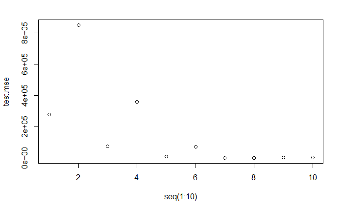

```r
plot(seq(1:10), test.mse)
```

The train MSE curve appears similar to what I expected, as the MSE gradually decreases as we increase the polynomial degree of the model’s function. However, the test MSE seems to follow no noticeable pattern. I decided to mess around with the irreducible error constant, and noticed that when I generate a new error, the test MSE values are very different! This increase in variance may be attributed to the higher degree of polynomial in the model’s equation.

# Problem 2

## 2a

```r
prostate = read.table('./prostate.data', header=TRUE)
head(prostate)
```

[output not shown]

```r
regfit = regsubsets(lpsa~., data=prostate, nbest=1, nvmax=8)
```

```r
n = dim(prostate)[1]
regfit.summary = summary(regfit)
p = rowSums(regfit.summary$which) - 1
adjr2 = regfit.summary$adjr2
mallows.cp = regfit.summary$cp
rss = regfit.summary$rss
AIC = n * log(rss/n) + 2*p
BIC = n * log(rss/n) + p*log(n)
cbind(p, rss, adjr2, mallows.cp, AIC, BIC)
```

[output not shown]

```r
which.min(AIC)
which.min(BIC)
which.min(mallows.cp)
which.max(adjr2)
```

[output not shown]

## 2b

```r
train = subset(prostate,train==TRUE)[,1:9]
test = subset(prostate,train==FALSE)[,1:9]
regfit.train = regsubsets(lpsa~., data=train, nbest=1, nvmax=8)
regfit.train.summary = summary(regfit.train)

n = dim(train)[1]
p = rowSums(regfit.train.summary$which) - 1
adjr2.2 = regfit.train.summary$adjr2
mallows.cp2 = regfit.train.summary$cp
rss2 = regfit.train.summary$rss
AIC2 = n * log(rss/n) + 2*p
BIC2 = n * log(rss/n) + p*log(n)
cbind(p, rss2, adjr2.2, mallows.cp2, AIC2, BIC2)
```

[output not shown]

```r
which.min(AIC2)
which.min(BIC2)
which.min(mallows.cp2)
which.max(adjr2.2)
```

[output not shown]

```r
model.2 = lm(lpsa~lcavol+lweight, data=train)
model.7 = lm(lpsa~.-gleason, data=train)

mse.2 = mean((test$lpsa - predict.lm(model.2, test)) ^ 2)
mse.2

mse.7 = mean((test$lpsa - predict.lm(model.7, test)) ^ 2)
mse.7
```

[output not shown]

```r
full.test.mse2 = mean((prostate$lpsa - predict.lm(model.2, prostate)) ^ 2)
full.test.mse2
```

[output not shown]

## 2c

```r
library(caret)
```

### 2ci

```r
k = 10
folds = sample(1:k, nrow(prostate), replace=TRUE)
val.errors = matrix(NA, k, 8)

for (i in 1:k) {

  test = prostate[folds==i, ]
  train = prostate[folds!=i, ]

  best.fit = regsubsets(lpsa~., train, nbest=1, nvmax=8)
  for (j in 1:8) {
    test.matrix = model.matrix(lpsa~., test)
    mc = coef(best.fit, id=j)
    ypred = test.matrix[, names(mc)]%*%mc
    val.errors[i, j] = mean((test$lpsa-ypred)**2)
  }
}
mean.vector = c()
for (i in 1:8) {
  mean.vector[[i]] = mean(val.errors[i,])
}
mean.vector
```

[output not shown]

### 2cii

```r
which.min(mean.vector)
minCV.err = which.min(mean.vector)
full.model = regsubsets(lpsa~., prostate, nbest=1, nvmax=8)
coef(full.model, minCV.err)
summary(full.model, minCV.err)
```

[output not shown]

# Problem 3

## 3a

K-fold cross-validation is a model selection strategy, in which we split the data set into k folds (k subsets), and then treat each subset as the test set, while the remainder of the data is the training set. Repeat this k times, so that each fold gets to be a test set, and we can ultimately test the model on all of our data.

## 3b

### 3bi

With k-fold, we can ensure that all the data gets treated as the test set at least once, whereas with validation set approach, we just randomly split the data into training and test once. Validation set approach can cause issues, because our split could contain certain values in the training set, such as outliers for instance, that mislead the model. However, k-fold is more computationally expensive than validation set, because you need to run k tests rather than just one.

### 3bii

With k-fold, we are still generalizing the data with our folds. We could encounter issues similar to the aforementioned ones in validation set approach (where the data in the specific set may be misleading, or contain many outliers that cause the model to determine correlations incorrectly), within one or more folds. Essentially, we could run into the same issue as validation sets, but within each fold. LOOCV fixes this issue, because we train the model on all the data except for one. This way, we can hollistically look at the entire data set for each test, and each individual datum gets to be the ‘test set’. Thus, any issues of a poor randomly allocated fold are eliminated. However, k-fold is better than LOOCV in terms of cost; LOOCV is extremely expensive computationally, as we need to train the model n times, where n is the length of the data set.

## 3c

```r
set.seed(1)
X = rnorm(100)
err = rnorm(n=100,mean=0,sd=1)
Y = X - 2 * (X ^ 2)
```

## 3d

```r
df = data.frame(X, Y)
set.seed(42)
mse.m1 = mse.m2 = mse.m3 = mse.m4 = rep(NA, n)
for (i in seq(1:n)) {
  test = df[i, ]
  train = df[-i, ]

  m1 = lm(Y~X, train)
  m2 = lm(Y~poly(X,2), train)
  m3 = lm(Y~poly(X,3), train)
  m4 = lm(Y~poly(X,4), train)

  m1.pred = predict(m1, test)
  m2.pred = predict(m2, test)
  m3.pred = predict(m3, test)
  m4.pred = predict(m4, test)

  mse.m1[i] = mean((test$Y - m1.pred) ^ 2)
  mse.m2[i] = mean((test$Y - m2.pred) ^ 2)
  mse.m3[i] = mean((test$Y - m3.pred) ^ 2)
  mse.m4[i] = mean((test$Y - m4.pred) ^ 2)
}

mean(mse.m1)
mean(mse.m2)
mean(mse.m3)
mean(mse.m4)
```

[output not shown]

## 3e

```r
set.seed(100)

mse.m1 = mse.m2 = mse.m3 = mse.m4 = rep(NA, n)
for (i in seq(1:n)) {
  test = df[i, ]
  train = df[-i, ]

  m1 = lm(Y~X, train)
  m2 = lm(Y~poly(X,2), train)
  m3 = lm(Y~poly(X,3), train)
  m4 = lm(Y~poly(X,4), train)

  m1.pred = predict(m1, test)
  m2.pred = predict(m2, test)
  m3.pred = predict(m3, test)
  m4.pred = predict(m4, test)

  mse.m1[i] = mean((test$Y - m1.pred) ^ 2)
  mse.m2[i] = mean((test$Y - m2.pred) ^ 2)
  mse.m3[i] = mean((test$Y - m3.pred) ^ 2)
  mse.m4[i] = mean((test$Y - m4.pred) ^ 2)
}

mean(mse.m1)
mean(mse.m2)
mean(mse.m3)
mean(mse.m4)
```

[output not shown]

## 3g

```r
PRESS = function(model, n){
  res = residuals(model)/(1 - lm.influence(model)$hat)
  sum(res^2)/n
}

m1 = lm(Y~X, df)
PRESS(m1, n)

m2 = lm(Y~poly(X,2), df)
PRESS(m2,n)

m3 = lm(Y~poly(X,3), df)
PRESS(m3,n)

m4 = lm(Y~poly(X,4), df)
PRESS(m4,n)

coefficients(m1)
coefficients(m2)
coefficients(m3)
coefficients(m4)
```

[output not shown]

# Problem 4

True. Although it is not common, because each method (AIC, BIC, Mallow’s Cp, ajdr^2) has a different formula for selecting models, there is a chance that they do not all agree on the model to select every single time.

## 4b

False. This would be true if, for instance, the first three predictors for both models were identical, but M4 had an additional predictor. However, because the first three predictors are not identical for both models, we cannot guarantee that M4 will have any lower of an RSS than M3.

## 4c

True. This would be true, for the opposite reasoning of part 4b. Here, both models share the predictors X4 and X5. Thus, adding new predictor(s), namely X6 and X7, can only reduce the RSS of the model. They cannot make the model any worse than it already is. Thus, M4 must have an RSS less than or equal to M2.